# Lab Four: Evaluation and Multi-Layer Perceptron

*Alec Evans, Jing Su, Omakoji John Idakwoji, Robert Lartigue*

```python
from sklearn.datasets import load_iris
from sklearn.metrics import accuracy_score, mean_squared_error, log_loss
from sklearn.preprocessing import StandardScaler
import numpy as np
import pandas as pd
import matplotlib.pyplot as plt
import seaborn as sns
from scipy.special import expit
import sys
```

## 1. Data Preparation and Overview

##### 1.1 Business Case and Classification Task

Our dataset consists of FIFA soccer player data for 17588 players each with 53 corresponding features.

The classification task of our neural network is to use the FIFA dataset to classify individual soccer players into three classes of rank: Elite, Pro, and Rookie. The greater the class the better the soccer player.

Our classification algorithm has business application in the sports betting industry. Every year billions of dollars are won and lost in the sports betting industry, which is on track to becoming a $51 billion industry by 2019[1]. In past years a booming area in this industry has been in fantasy sports, in which a participants draft teams of players and bet of the outcome of their teams season.

Team performance is measured by the success of individual players on the team, which uses a point ranking system in which players are rewarded points for good plays, scoring goals, ect. Thus, the better the individual players on a team, the higher likelihood your team will outperform others. The difficulty of fantasy sports arises in choosing the best lineup with respect to an alloted budget/salary cap. Each player, based on their skills/ability cost varying amounts, with the best players costing the most.

Most participants rely on personal intuition when drafting players for his or her team. Using our classification algorithm, participants could select the highest skilled players with the lowest cost, allowing them to select more higher quality players while optimizing their budget.

Since predicting a players' skill classification is the cornerstone of our end application, we know that our accuracy needs to be quite high. This classification will be used to feed many other insights and recommendations along the way, and if our initial classifications are inaccurate, then our product/application will become increasingly inferior to our competitors. If we were attempting to be the first fantasy soccer prediction machine going to market, we could probably sacrifice some accuracy to deploy to the market faster, but since fantasy soccer is already a huge business, with many competitors offering up similar prediction models and fantasy lineup optimizers, we would need our accuracy to be very high in order to gain and retain customers who would subscribe to our product[2].

##### possible Extensions

Additionally, we could import fantasy player cost data into our dataset and make player recommendations during the draft. We could identify the best player available, based on the participants remaining budget and what positions the participant still needs for their lineup.

Lastly, we could analyze game data from the past to identify relationships between opponents. Do players/teams perform better against poor teams? Do players/teams perform below average against tough opponents? This would allow us to scale a players rating up or down based on their upcoming opponents, therefore making our lineup recommendations that much more powerful.

[1] https://www.statista.com/topics/1368/gambling/ [2] https://www.rotowire.com/daily/soccer/optimizer.php?site=DraftKings&league=EPL

###### 1.2 Import the dataset

```python
# Load the Dataset
df = pd.read_csv('FullData.csv')
```

```python
# View the current columns of the dataset prior to cleaning
df.info()
```

```
<class 'pandas.core.frame.DataFrame'>
RangeIndex: 17588 entries, 0 to 17587
Data columns (total 53 columns):
Name                  17588 non-null object
Nationality           17588 non-null object
National_Position     1075 non-null object
National_Kit          1075 non-null float64
Club                  17588 non-null object
Club_Position         17588 non-null object
Club_Kit              17587 non-null float64
Club_Joining          17587 non-null object
Contract_Expiry       17587 non-null float64
Rating                17588 non-null int64
Height                17588 non-null object
Weight                17588 non-null object
Preffered_Foot        17588 non-null object
Birth_Date            17588 non-null object
Age                   17588 non-null int64
Preffered_Position    17588 non-null object
Work_Rate             17588 non-null object
Weak_foot             17588 non-null int64
Skill_Moves           17588 non-null int64
Ball_Control          17588 non-null int64
Dribbling             17588 non-null int64
Marking               17588 non-null int64
Sliding_Tackle        17588 non-null int64
Standing_Tackle       17588 non-null int64
Aggression            17588 non-null int64
Reactions             17588 non-null int64
Attacking_Position    17588 non-null int64
Interceptions         17588 non-null int64
Vision                17588 non-null int64
Composure             17588 non-null int64
Crossing              17588 non-null int64
Short_Pass            17588 non-null int64
Long_Pass             17588 non-null int64
Acceleration          17588 non-null int64
Speed                 17588 non-null int64
Stamina               17588 non-null int64
Strength              17588 non-null int64
Balance               17588 non-null int64
Agility               17588 non-null int64
Jumping               17588 non-null int64
Heading               17588 non-null int64
Shot_Power            17588 non-null int64
Finishing             17588 non-null int64
Long_Shots            17588 non-null int64
Curve                 17588 non-null int64
Freekick_Accuracy     17588 non-null int64
Penalties             17588 non-null int64
Volleys               17588 non-null int64
GK_Positioning        17588 non-null int64
GK_Diving             17588 non-null int64
GK_Kicking            17588 non-null int64
GK_Handling           17588 non-null int64
GK_Reflexes           17588 non-null int64
dtypes: float64(3), int64(38), object(12)
memory usage: 7.1+ MB
```

###### 1.3 Reduce number of position types

```python
# Categorize the players club position into

player_position = dict(zip(['LW', 'RS', 'LS', 'RW', 'LF', 'CF', 'ST', 'RF'] + \
                ['RCM', 'CDM', 'CAM', 'RDM', 'LCM', 'CM', 'LM', 'LDM', 'RM', 'RAM', 'LAM'] + \
                ['LCB', 'RCB', 'LB', 'RB', 'CB', 'RCB', 'RWB', 'LWB'] + \
                ['GK'], ['Attack'] * 8 + ['Middles'] * 11 + ['Backs'] * 8 + ['Keeper']))

df['Position_Group'] = df.apply(lambda row: player_position.get(row['Club_Position'], row['Club_Position']), axis=1)
```

###### 1.4 Remove variables from the dataset not needed for logistic regression

```python
del df['Name']
del df['Nationality']
del df['National_Position']
del df['National_Kit']
del df['Club']
del df['Club_Kit']
del df['Club_Joining']
del df['Contract_Expiry']
del df['Preffered_Position']
del df['Birth_Date']
del df['Club_Position']
```

###### 1.5 Eliminate the units for height and weight

Grab the numeric value of height and weight and get rid of the units so these values can be represented as integer values.

```python
df.Height.head()
```

```
0    185 cm
1    170 cm
2    174 cm
3    182 cm
4    193 cm
Name: Height, dtype: object
```

```python
#df.Last_login = df.Last_login.apply(lambda x: x.split('_')[1]).astype(int)
df.Height = df.Height.apply(lambda x: x.split(' ')[0]).astype(int)
df.Weight = df.Weight.apply(lambda x: x.split(' ')[0]).astype(int)
df.Height.head()
```

```
0    185
1    170
2    174
3    182
4    193
Name: Height, dtype: int64
```

###### 1.6 One hot encode Position Group

```python
# Get the location of the column to one hot encode, so we know where to add the one hot encoded values in the dataframe to keep with convention
print(df.columns.get_loc('Position_Group'))
```

```
42
```

```python
# One hot encodingn for position group
df = pd.concat([df.iloc[:, :42], pd.get_dummies(df.Position_Group), df.iloc[:, 42:]], axis=1)
```

```python
# Delete position group column as it is uneeded
del df['Position_Group']
```

###### 1.7 Represent the players preffered foot as binary

```python
# Make the players preffered foot binary
df.Preffered_Foot = df.Preffered_Foot.apply(lambda x: 0 if x == 'Left' else 1)
```

```python
len(df.columns)
```

```
48
```

###### 1.8 Process Work Rate and one hot encode the values

Work rate is given in the form of 'offensive work rate / defensive work rate' in the original dataset. In order to make use of these values, we separate the offensive work rate and defensive work rate and make a new column for each. Then using the work rate values in the new column the values are one hot encoded.

```python
df.Work_Rate.head()
```

```
0         High / Low
1    Medium / Medium
2      High / Medium
3      High / Medium
4    Medium / Medium
Name: Work_Rate, dtype: object
```

```python
# Seperate work rate into offensive and defensive categories
WR_O = df.Work_Rate.apply(lambda x: x.split(' /')[0]).astype(str)
WR_D = df.Work_Rate.apply(lambda x: x.split('/ ')[1]).astype(str)
df.insert(48,'WR_ATT', WR_O)
df.insert(49, 'WR_DEF', WR_D)
```

```python
# One hot encode the work rate for offensive and defensive positions
df = pd.concat([df.iloc[:, :48], pd.get_dummies(df.WR_ATT), df.iloc[:, 48:]], axis=1)
df = df.rename(columns={'Low':'Att_Low', 'Medium': 'Att_Med', 'High': 'Att_High'})
df = pd.concat([df.iloc[:, :49], pd.get_dummies(df.WR_DEF), df.iloc[:, 49:]], axis=1)
df = df.rename(columns={'Low':'Def_Low', 'Medium': 'Def_Med', 'High': 'Def_High'})
```

```python
# Drop original columns
# Delete the source columns used for one hot encoding
del df['WR_ATT']
del df['WR_DEF']
del df['Work_Rate']
```

###### 1.9 Classifying the players

Using the player rating we classify the players into 3 classes. Players with rating 75 or greater are of class 2 (Elite), players with rating 74-61 are of class 1 (Pro), and players with rating 60 or less are of class 0 (Rookie). The class limits were chosen with the aid of the distribution plot of the player rating and the describe method.

```python
df.Rating.describe()
```

```
count    17588.000000
mean        66.166193
std          7.083012
min         45.000000
25%         62.000000
50%         66.000000
75%         71.000000
max         94.000000
Name: Rating, dtype: float64
```

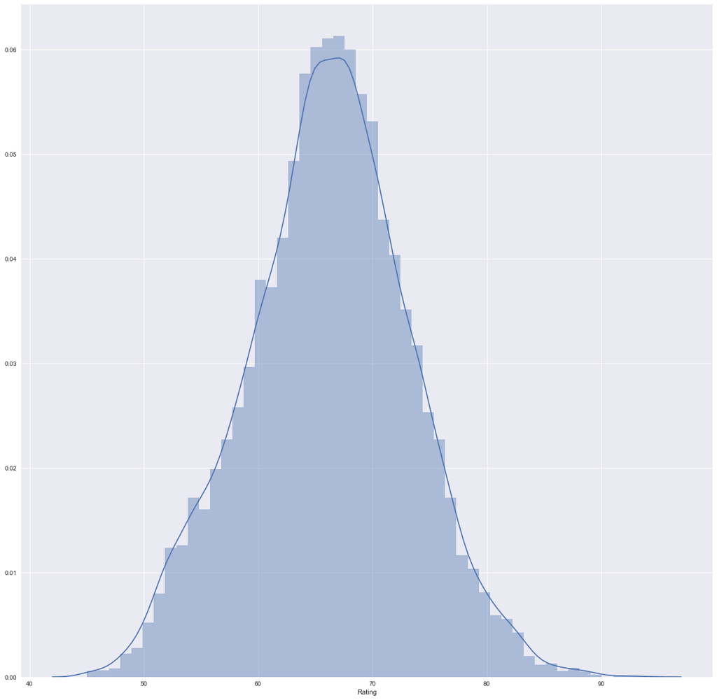

```python
sns.distplot(df.Rating)
plt.show()
```

```python
# Classify the players skill into 3 classes
# 2 = best
# 1 = mid
# 0 = worst

player_class = []
for i in range(len(df)):
    if df.Rating[i] >= 75:
        player_class.append(2)
    elif df.Rating[i] <= 60:
        player_class.append(0)
    else:
        player_class.append(1)

df.insert(53,'Player_Class', player_class)
```

```python
# Create a new dataframe without rating and player class
X = df.copy()
del X['Rating']
del X['Player_Class']
```

```python
# Create our target variable
y = df['Player_Class']
```


## 2. Evaluation

###### 2.1. Evaluation Metric

In choosing an appropriate evaluation metric to evaluate our algorithms generalization performance, it is important to first understand the algorithms classification task and what we are trying to accomplish. The classification task of our algorithm, as stated in our business case, is to classify soccer players into three classes of corresponding skill level: Elite, Pro, and Rookie. Also, in our business case, we stated that our algorithm needs to be as accurate as possible in order to remain competitive with the many other deployed fantasy lineup drafting algorithms on the market today. Critical to choosing an evaluation metric to evaluate our algorithms generalization performance, we need to define exactly what accuracy means pertaining to our dataset. To further understand accuracy as it applies to our dataset, lets next look at the class distribution of players.

```python
# Class distribution
y.value_counts()
```

```
1    11866
0     3692
2     2030
Name: Player_Class, dtype: int64
```

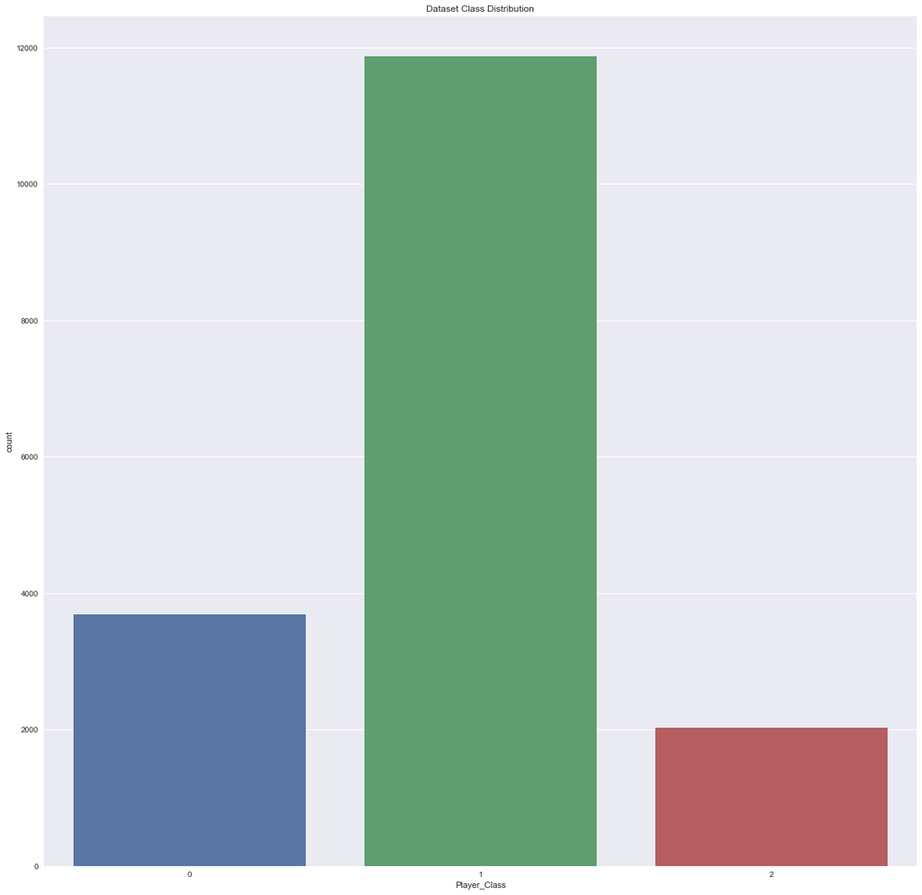

```python
# Plot the distribution
sns.countplot(y)
plt.title('Dataset Class Distribution')
plt.show()
```

As can be seen from the distribution of classes in our dataset, there is an immense class imbalance between the classes. When we created our classes for our dataset (Elite (2), Pro (1), Rookie (0)), we created them based on loosely determined values that we felt effectively separated tiers of players in our dataset. In doing so, we unintentionally created a class imbalance in our tiers. The Elite class (2) having 2030 instances, the Pro class (1) having 11,866 instances, and the Rookie class (0) having 3692 instances.

Due to this class imbalance, we chose to use the macro averaged F1-Score as the evaluation metric for our algorithms performance. Using macro averaging allows for the precision in each class to be weighted equally across all classes. Thus a macro averaged F1 score computes the precision and recall metrics independently for each class, then takes the average, hence treating all classes equally. Thus even though class 1 has 11,866 instances and class 2 has 2030, the our algorithms classification performance for each of the classes gets the same weight in the macro averaged F1-Score. Therefore, the bias of the instance imbalance of the classes is removed from the evaluation of out dataset. To calculate the macro averaged F1-Score for our algorithm the harmonic mean is taken of the Macro averaged precision and recall shown below:

$$ Macro \hspace{2mm} Averaged \hspace{2mm} Precision = \frac{P\hspace{2mm}(Class\hspace{2mm}0) + P\hspace{2mm}(Class\hspace{2mm}1) + P\hspace{2mm}(Class\hspace{2mm}2)} 3$$$$ Macro \hspace{2mm} Averaged \hspace{2mm} Recall = \frac{R\hspace{2mm}(Class\hspace{2mm}0) + R\hspace{2mm}(Class\hspace{2mm}1) + R\hspace{2mm}(Class\hspace{2mm}2)} 3$$

In terms of the business case we argued for, we believe this is the appropriate evaluation metric to best capture the actual classification accuracy across our classes. To further understand why a macro averaged F1-Score is a more appropriate evaluation metric for our algorithm as opposed to lets say accuracy, lets take a step back.

Consider we chose accuracy as the evaluation metric for our algorithm. If we correctly classified all the instances in class 1 and class 0, and misclassified all the instances in class 2, our algorithm would have a classification accuracy score of:

$$ \frac{11866 + 3692} {11866 + 3692 + 2030} = 0.88 $$

or 88 %. Wow! 88% percent accuracy!

While 88 % accuracy gives the perception that our algorithm is very accurately classifying players, it is in fact not because it was not able to correctly classify any class 2 instances. For this reason, accuracy can be very misleading when working with datasets with large class imbalances as seen in ours.

Thus, in terms of the business case, our algorithm would need to accurately classify players across ALL classes equally well to be an effective and deplorable fantasy lineup drafting algorithm. Which is why the appropriate evaluation metric for our algorithms generalization performance is the macro averages F1-Score.

###### 2.2. Method for Generating Training and Testing Sets

Again we choosing an appropriate method for generating training and testing sets from our dataset, it is crucial to keep in mind the immense class imbalance in our dataset. Due to this class imbalance, the appropriate method for splitting our data into training and testing sets in Stratified K-Fold Cross-Validation.

Similar to the K-Fold cross validation technique, where the data is split into K number of folds, where K-1 folds are used for training and 1 fold is used for testing, stratified K-Fold cross validation performs the same splitting of the data. However, in stratified K-Fold techniques, each fold is representative of the original dataset. Thus, if the dataset is 90 % class A and 10 % class B, Stratified K-Fold Cross-Validation ensures that each fold will also have 90 % class A instances and 10 % class B instances, mirroring the original distribution of the dataset. This is greatly important when dealing with class imbalances in datasets, because it ensures no folds are 100 % class A and 0 % class B, which makes for a poor representation of the original dataset, and therefore a poor classifier.

Works Cited: Precision-Recall: http://scikit-learn.org/stable/auto_examples/model_selection/plot_precision_recall.html

F1 Score: http ://scikit-learn.org/stable/modules/generated/sklearn.metrics.f1_score.html#sklearn.metrics.f1_score

K-Fold CV: http://scikit-learn.org/stable/modules/cross_validation.html#cross-validation

## 3. Modeling

###### 3.1 Custom Multi Layer Perceptron Implementation

```python
class CustomNLayerPerceptron(object):
    def __init__(self, n_neurons = 50, n_hidden_layers = 1, C = 0.1, epochs = 10, eta = 0.01, random_state = 1, phi = 'sigmoid', cost = 'quad'):
        np.random.seed(random_state)
        self.n_neurons = n_neurons
        self.n_hidden_layers = n_hidden_layers
        self.C = C
        self.epochs = epochs
        self.eta = eta
        self.phi = phi
        self.cost = cost

    @staticmethod
    def _encode_labels(y):

        onehot = pd.get_dummies(y).values.T
        return onehot

    @staticmethod
    def _initialize_weights(self):
        W = []
        # Initial Layer
        W1_num_elems = (self.n_features_ + 1) * self.n_neurons
        W1 = np.random.uniform(-1.0, 1.0, size = W1_num_elems)
        W1 = W1.reshape(self.n_neurons, self.n_features_ + 1)
        W.append(W1)

        # Hidden Layers
        for i in range(self.n_hidden_layers - 1):
            W_hidden_num_elems = ((self.n_neurons + 1) * (self.n_neurons))
            W_hidden = np.random.uniform(-1.0, 1.0, size = W_hidden_num_elems)
            W_hidden = W_hidden.reshape(self.n_neurons, self.n_neurons + 1) # Number of hiddden neurons + bias x number of hidden neurons + bias
            W.append(W_hidden)

        # Final Layer
        W2_num_elems = (self.n_neurons + 1) * self.n_output_
        W2 = np.random.uniform(-1.0, 1.0, size = W2_num_elems)
        W2 = W2.reshape(self.n_output_, self.n_neurons + 1)
        W.append(W2)

        self.W_ = W

        return W


    # Activation Function Selection
    def _activation(self, z):
        if self.phi == 'sigmoid':
            return self._phi_sigmoid(z)
        elif self.phi == 'linear':
            return self._phi_linear(z)
        elif self.phi == 'ReLU':
            return self._phi_ReLU(z)
        elif self.phi == 'Swish':
            return self._phi_Swish(z)

    @staticmethod
    def _phi_sigmoid(z):
        return expit(z)

    @staticmethod # without this here I got an error saying _phi_linear() takes 1 positional argument but 2 were given... interesting??
    def _phi_linear(z):
        return z

    @staticmethod
    def _phi_ReLU(z):
        return np.maximum(0,z.copy()) # this way is better

    @staticmethod
    def _phi_Swish(z):
        return z*expit(z)

    # Cost Function Selection
    def _cost(self, A, Y_enc, W):
        if self.cost == 'quad':
            return self._cost_quadratic(A, Y_enc, W)
        elif self.cost == 'crossentropy':
            return self._cost_cross_entropy(A, Y_enc, W)

    def _cost_quadratic(self, A, Y_enc, W):
        cost = np.mean((Y_enc - A) ** 2)
        L2_term = self._L2_reg(self.C, W)
        return cost + L2_term

    def _cost_cross_entropy(self, A3, Y_enc, W):
        cost = -np.mean(np.nan_to_num((Y_enc*np.log(A3)+(1-Y_enc)*np.log(1-A3))))
        L2_term = self._L2_reg(self.C, W)
        return cost + L2_term

    def _L2_reg(self, C, W):
        mean = 0
        for w in self.W:
            mean += np.mean(w[:, 1:] ** 2)
        return(C/len(self.W) * np.sqrt(mean))

    @staticmethod
    def _add_bias_unit(X, how = 'column'):
        if how == 'column':
            ones = np.ones((X.shape[0], 1))
            X_new = np.hstack((ones,X)) # horizontal stack
        elif how == 'row':
            ones = np.ones((1, X.shape[1]))
            X_new = np.vstack((ones, X)) # vertical stack
        return X_new

    def _feedforward(self, X, W):
        A = []
        Z = []

        A1 = self._add_bias_unit(X.T, how = 'row')
        A.append(A1)
        Z1 = W[0] @ A[0]
        Z.append(Z1)

        for idx in range(self.n_hidden_layers):
            Ah = self._activation(Z[idx])
            Ah = self._add_bias_unit(Ah, how = 'row')
            A.append(Ah)
            Zh = W[idx+1] @ A[idx + 1]
            Z.append(Zh)

        A.append(self._activation(Z[-1]))

        self.A_ = A
        self.Z_ = Z

        return A, Z

    def _get_gradient(self, A, Z, W, Y_enc):

        V = self.W.copy()
        G = self.W.copy()

        V[-1] = self._get_cost_derivative(A[-1], Y_enc) * self._activation_derivative(A[-1])
        G[-1] = V[-1] @ A[-2].T
        G[-1] += W[-1] * self.C



        for i in range(-2, -self.n_hidden_layers-2, -1):
            if i == -2:
                V[i] = (self._activation_derivative(A[i])) * (W[i+1].T @ V[i+1])
            else:
                V[i] = (self._activation_derivative(A[i])) * (W[i+1].T @ V[i+1][1:,:])

            G[i] = V[i][1:, :] @ A[i-1].T
            G[i][:, 1:] += W[i][:, 1:] * self.C

        self.G_ = G

        return G

    def _get_cost_derivative(self, A, Y_enc):
        if self.cost == 'quad':
            cost_deriv = -2 * (Y_enc - A)
            return cost_deriv
        elif self.cost == 'crossentropy':
            cost_deriv = A - Y_enc
            return cost_deriv

    def _activation_derivative(self, A):
        if self.phi == 'sigmoid':
            act_deriv = A * (1 - A)
            return act_deriv
        elif self.phi == 'linear':
            act_deriv = A * 1.0
            return act_deriv
        elif self.phi == 'ReLU':
            act_deriv = (A > 0) * 1.0
            return act_deriv
        elif self.phi == 'Swish':
            act_deriv = ((A * expit(A)) + expit(A) * (1 - (A * expit(A))))
            return act_deriv

    def predict(self, X):
        _, A = self._feedforward(X, self.W)
        y_pred = np.argmax(A[-1], axis = 0)
        return y_pred

    def fit(self, X, y):
        X_data, y_data = X.copy(), y.copy()
        Y_enc = self._encode_labels(y)
        self.n_features_ = X_data.shape[1]
        self.n_output_ = Y_enc.shape[0]
        self.W = self._initialize_weights(self)

        self.cost_ = []
        self.G1_avg_ = []
        self.G2_avg_ = []
        self.G3_avg_ = []
        self.G4_avg_ = []

        for i in range(self.epochs):
            A, Z = self._feedforward(X_data, self.W)
            cost = self._cost(A[-1], Y_enc, self.W)
            self.cost_.append(cost)
            self.G = self._get_gradient(A = A, Z = Z, Y_enc = Y_enc, W = self.W)
            # This is for plotting the gradients with out optimal parameters
            if (len(self.G)) == 1:
                self.G1_avg_.append(abs(np.mean(self.G[0])))
            elif (len(self.G)) == 2:
                self.G1_avg_.append(abs(np.mean(self.G[0])))
                self.G2_avg_.append(abs(np.mean(self.G[1])))
            elif (len(self.G)) == 3:
                self.G1_avg_.append(abs(np.mean(self.G[0])))
                self.G2_avg_.append(abs(np.mean(self.G[1])))
                self.G3_avg_.append(abs(np.mean(self.G[2])))
            elif (len(self.G)) == 4:
                self.G1_avg_.append(abs(np.mean(self.G[0])))
                self.G2_avg_.append(abs(np.mean(self.G[1])))
                self.G3_avg_.append(abs(np.mean(self.G[2])))
                self.G4_avg_.append(abs(np.mean(self.G[3])))
            else:
                pass

            for idx in range(self.n_hidden_layers+1):
                self.W[idx] -= self.eta * self.G[idx]
        return self

    def get_params(self, deep = True):
        return {'n_neurons': self.n_neurons,
                'n_hidden_layers': self.n_hidden_layers,
                'C': self.C,
                'epochs': self.epochs,
                'eta': self.eta,
                'phi': self.phi,
                'cost': self.cost}

    def set_params(self, **params):
        for param, value in params.items():
            self.__setattr__(param, value)

        return self

# Code Reference: Eric Larson: https://github.com/eclarson/MachineLearningNotebooks/blob/master/07.%20MLP%20Neural%20Networks.ipynb
```

###### 3.2 Hyperparameter Tuning

```python
from sklearn.metrics import make_scorer,f1_score
from sklearn.model_selection import GridSearchCV
from sklearn.pipeline import make_pipeline
from sklearn.metrics import make_scorer, f1_score
from sklearn.pipeline import Pipeline
from sklearn.model_selection import cross_val_score
```

Before we begin to tune the hyperparameters for the phi function, objective function, and the number of layers, we are first going to determine the values held constant for C, epochs, eta, and the number of neurons. This will help determine optimal values for these metrics and also save significant time in the grid search.

```python
X_train, X_test, y_train, y_test = train_test_split(X, y, test_size = 0.2, random_state = 1)
```

```python
C = CustomNLayerPerceptron(C=0.1, cost='crossentropy', epochs=500, eta=0.0001, n_hidden_layers=2, n_neurons=50, phi='sigmoid', random_state=1)
C.fit(X_train,y_train)
yhat = C.predict(X_test)
f1_score(y_test, yhat, average = 'macro')
```

```
0.71446033058743019
```

To tune the remaining hyperparameters we chose to use a grid search to find the values of the phi function, objective function, and the number of layers.

```python
# Commented out as reminder to not run twice. We have save the grid search locally in an excel file

# %%time
# params = {
#     'n_neurons': [50],
#     'n_hidden_layers': [1, 2, 5],
#     'C': [0.1],
#     'epochs': [500],
#     'eta': [0.0001],
#     'phi': ['sigmoid', 'linear', 'ReLU', 'Swish'],
#     'cost': ['quad', 'crossentropy']
# }

# NN = CustomNLayerPerceptron()
# scorer = make_scorer(f1_score, average = 'macro')
# cv = StratifiedKFold(n_splits = 3)
# NN_Grid = GridSearchCV(NN, params, scoring = scorer, cv=cv)
# NN_Grid.fit(X,y)
# NN_GridSearch = pd.DataFrame(NN_Grid.cv_results_)
```

```python
NN_Grid.best_params_
```

```
{'C': 0.1,
 'cost': 'crossentropy',
 'epochs': 500,
 'eta': 0.0001,
 'n_hidden_layers': 2,
 'n_neurons': 50,
 'phi': 'sigmoid'}
```

```python
# writer = pd.ExcelWriter('NN_GridSearch.xlsx')
# NN_GridSearch.to_excel(writer,'Sheet1')
# writer.save()
# writer.close()
```

```python
# Upload the NN Grid Search results from the excel file
NN_GridSearchExcel = pd.ExcelFile('NN_GridSearch.xlsx')
NN_GridSearchExcel = NN_GridSearchExcel.parse('Sheet1')
```

```python
# create a new column in our grid search dataframe for plotting purposes
new_col = ["1L_Sig_Quad",
          "1L_Lin_Quad",
          "1L_ReLU_Quad",
          "1L_Swish_Quad",
          "2L_Sig_Quad",
          "2L_Lin_Quad",
          "2L_ReLU_Quad",
          "2L_Swish_Quad",
          "5L_Sig_Quad",
          "5L_Lin_Quad",
          "5L_ReLU_Quad",
          "5L_Swish_Quad",
          "1L_Sig_CrossE",
          "1L_Lin_CrossE",
          "1L_ReLU_CrossE",
          "1L_Swish_CrossE",
          "2L_Sig_CrossE",
          "2L_Lin_CrossE",
          "2L_ReLU_CrossE",
          "2L_Swish_CrossE",
          "5L_Sig_CrossE",
          "5L_Lin_CrossE",
          "5L_ReLU_CrossE",
          "5L_Swish_CrossE"]
NN_GridSearchExcel.insert(loc=0, column='ParamCombination', value=new_col)
```

```python
NN_GridSearchExcel
```

|  | ParamCombination | mean_fit_time | mean_score_time | mean_test_score | mean_train_score | param_C | param_cost | param_epochs | param_eta | param_n_hidden_layers | ... | split0_test_score | split0_train_score | split1_test_score | split1_train_score | split2_test_score | split2_train_score | std_fit_time | std_score_time | std_test_score | std_train_score |
| --- | --- | --- | --- | --- | --- | --- | --- | --- | --- | --- | --- | --- | --- | --- | --- | --- | --- | --- | --- | --- | --- |
| 0 | 1L_Sig_Quad | 10.486861 | 0.012567 | 0.393430 | 0.454524 | 0.1 | quad | 500 | 0.0001 | 1 | ... | 0.382741 | 0.507828 | 0.409538 | 0.473924 | 0.388013 | 0.381821 | 0.634659 | 0.000895 | 0.011591 | 0.053240 |
| 1 | 1L_Lin_Quad | 5.874450 | 0.006142 | 0.115664 | 0.115664 | 0.1 | quad | 500 | 0.0001 | 1 | ... | 0.115668 | 0.115662 | 0.115685 | 0.115654 | 0.115640 | 0.115676 | 1.172831 | 0.001261 | 0.000019 | 0.000009 |
| 2 | 1L_ReLU_Quad | 7.231966 | 0.010136 | 0.268577 | 0.268577 | 0.1 | quad | 500 | 0.0001 | 1 | ... | 0.268568 | 0.268582 | 0.268554 | 0.268588 | 0.268609 | 0.268561 | 0.569808 | 0.001468 | 0.000023 | 0.000012 |
| 3 | 1L_Swish_Quad | 18.797754 | 0.012218 | 0.268577 | 0.268577 | 0.1 | quad | 500 | 0.0001 | 1 | ... | 0.268568 | 0.268582 | 0.268554 | 0.268588 | 0.268609 | 0.268561 | 2.197792 | 0.002666 | 0.000023 | 0.000012 |
| 4 | 2L_Sig_Quad | 18.453117 | 0.016441 | 0.428703 | 0.528820 | 0.1 | quad | 500 | 0.0001 | 2 | ... | 0.399158 | 0.543717 | 0.575082 | 0.566199 | 0.311834 | 0.476543 | 0.826656 | 0.002013 | 0.109477 | 0.038087 |
| 5 | 2L_Lin_Quad | 9.114173 | 0.010414 | 0.115664 | 0.115664 | 0.1 | quad | 500 | 0.0001 | 2 | ... | 0.115668 | 0.115662 | 0.115685 | 0.115654 | 0.115640 | 0.115676 | 0.606289 | 0.001838 | 0.000019 | 0.000009 |
| 6 | 2L_ReLU_Quad | 13.866602 | 0.017571 | 0.115664 | 0.115664 | 0.1 | quad | 500 | 0.0001 | 2 | ... | 0.115668 | 0.115662 | 0.115685 | 0.115654 | 0.115640 | 0.115676 | 1.420119 | 0.002078 | 0.000019 | 0.000009 |
| 7 | 2L_Swish_Quad | 31.746264 | 0.017572 | 0.268577 | 0.268577 | 0.1 | quad | 500 | 0.0001 | 2 | ... | 0.268568 | 0.268582 | 0.268554 | 0.268588 | 0.268609 | 0.268561 | 1.953566 | 0.002542 | 0.000023 | 0.000012 |
| 8 | 5L_Sig_Quad | 46.965711 | 0.038146 | 0.359170 | 0.363731 | 0.1 | quad | 500 | 0.0001 | 5 | ... | 0.378318 | 0.413994 | 0.321661 | 0.333763 | 0.377534 | 0.343435 | 3.388093 | 0.004420 | 0.026526 | 0.035760 |
| 9 | 5L_Lin_Quad | 27.025451 | 0.023205 | 0.115664 | 0.115664 | 0.1 | quad | 500 | 0.0001 | 5 | ... | 0.115668 | 0.115662 | 0.115685 | 0.115654 | 0.115640 | 0.115676 | 1.037096 | 0.003296 | 0.000019 | 0.000009 |
| 10 | 5L_ReLU_Quad | 38.603832 | 0.031893 | 0.068984 | 0.068984 | 0.1 | quad | 500 | 0.0001 | 5 | ... | 0.069001 | 0.068976 | 0.069011 | 0.068971 | 0.068941 | 0.069006 | 3.428206 | 0.002628 | 0.000031 | 0.000015 |
| 11 | 5L_Swish_Quad | 89.644130 | 0.033269 | 0.268577 | 0.268577 | 0.1 | quad | 500 | 0.0001 | 5 | ... | 0.268568 | 0.268582 | 0.268554 | 0.268588 | 0.268609 | 0.268561 | 5.802208 | 0.002245 | 0.000023 | 0.000012 |
| 12 | 1L_Sig_CrossE | 9.751921 | 0.010915 | 0.418349 | 0.543168 | 0.1 | crossentropy | 500 | 0.0001 | 1 | ... | 0.356515 | 0.541887 | 0.425150 | 0.493085 | 0.473410 | 0.594530 | 0.574708 | 0.000943 | 0.047963 | 0.041425 |
| 13 | 1L_Lin_CrossE | 6.066994 | 0.006136 | 0.115664 | 0.115664 | 0.1 | crossentropy | 500 | 0.0001 | 1 | ... | 0.115668 | 0.115662 | 0.115685 | 0.115654 | 0.115640 | 0.115676 | 0.577858 | 0.001101 | 0.000019 | 0.000009 |
| 14 | 1L_ReLU_CrossE | 6.859702 | 0.010856 | 0.268577 | 0.268577 | 0.1 | crossentropy | 500 | 0.0001 | 1 | ... | 0.268568 | 0.268582 | 0.268554 | 0.268588 | 0.268609 | 0.268561 | 0.246296 | 0.000313 | 0.000023 | 0.000012 |
| 15 | 1L_Swish_CrossE | 15.917747 | 0.011973 | 0.268577 | 0.268577 | 0.1 | crossentropy | 500 | 0.0001 | 1 | ... | 0.268568 | 0.268582 | 0.268554 | 0.268588 | 0.268609 | 0.268561 | 1.292100 | 0.002526 | 0.000023 | 0.000012 |
| 16 | 2L_Sig_CrossE | 18.527705 | 0.015420 | 0.513544 | 0.519689 | 0.1 | crossentropy | 500 | 0.0001 | 2 | ... | 0.326452 | 0.511758 | 0.630710 | 0.627392 | 0.583526 | 0.419917 | 1.317655 | 0.002304 | 0.133711 | 0.084887 |
| 17 | 2L_Lin_CrossE | 10.312563 | 0.008960 | 0.115664 | 0.115664 | 0.1 | crossentropy | 500 | 0.0001 | 2 | ... | 0.115668 | 0.115662 | 0.115685 | 0.115654 | 0.115640 | 0.115676 | 0.611810 | 0.001259 | 0.000019 | 0.000009 |
| 18 | 2L_ReLU_CrossE | 13.369669 | 0.015153 | 0.115664 | 0.115664 | 0.1 | crossentropy | 500 | 0.0001 | 2 | ... | 0.115668 | 0.115662 | 0.115685 | 0.115654 | 0.115640 | 0.115676 | 1.324626 | 0.001630 | 0.000019 | 0.000009 |
| 19 | 2L_Swish_CrossE | 30.745067 | 0.017301 | 0.268577 | 0.268577 | 0.1 | crossentropy | 500 | 0.0001 | 2 | ... | 0.268568 | 0.268582 | 0.268554 | 0.268588 | 0.268609 | 0.268561 | 2.353424 | 0.002732 | 0.000023 | 0.000012 |
| 20 | 5L_Sig_CrossE | 49.791686 | 0.042670 | 0.419052 | 0.420465 | 0.1 | crossentropy | 500 | 0.0001 | 5 | ... | 0.572221 | 0.541041 | 0.375371 | 0.450091 | 0.309500 | 0.270264 | 2.077581 | 0.009215 | 0.111613 | 0.112512 |
| 21 | 5L_Lin_CrossE | 27.524073 | 0.024359 | 0.115664 | 0.115664 | 0.1 | crossentropy | 500 | 0.0001 | 5 | ... | 0.115668 | 0.115662 | 0.115685 | 0.115654 | 0.115640 | 0.115676 | 1.901299 | 0.000748 | 0.000019 | 0.000009 |
| 22 | 5L_ReLU_CrossE | 37.809917 | 0.028951 | 0.068984 | 0.068984 | 0.1 | crossentropy | 500 | 0.0001 | 5 | ... | 0.069001 | 0.068976 | 0.069011 | 0.068971 | 0.068941 | 0.069006 | 2.082573 | 0.005618 | 0.000031 | 0.000015 |
| 23 | 5L_Swish_CrossE | 83.906049 | 0.031554 | 0.268577 | 0.268577 | 0.1 | crossentropy | 500 | 0.0001 | 5 | ... | 0.268568 | 0.268582 | 0.268554 | 0.268588 | 0.268609 | 0.268561 | 3.658500 | 0.003915 | 0.000023 | 0.000012 |

24 rows × 24 columns

###### 3.3 Visualization of F1-Score vs. hyper parameters

```python
NN_GridSearchExcel = NN_GridSearchExcel.sort_values(['mean_test_score'], ascending = False).reset_index(drop=True)
```

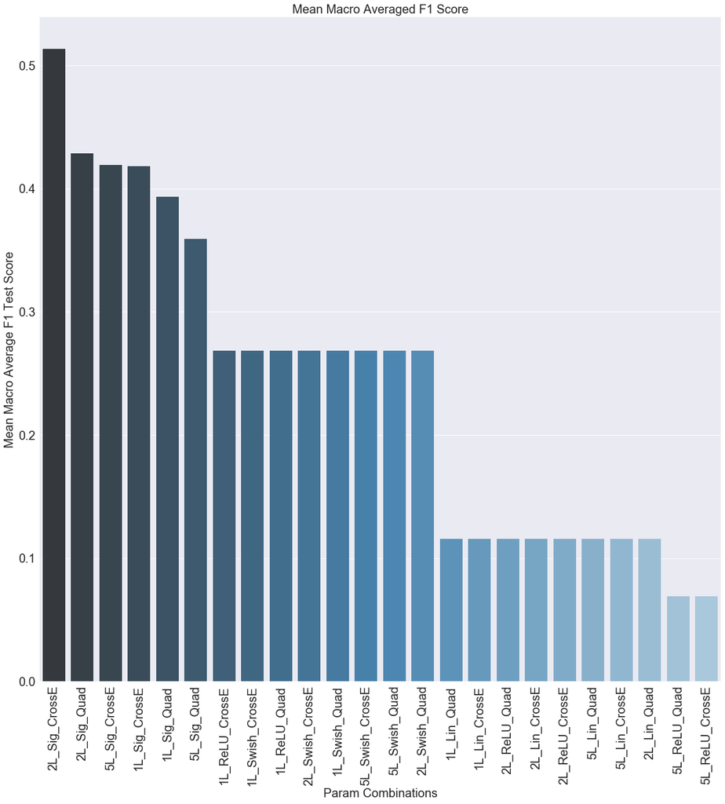

```python
import seaborn as sns

A = sns.barplot(x = 'ParamCombination', y = 'mean_test_score',
                data = NN_GridSearchExcel, palette = 'Blues_d')

sns.set(rc={'figure.figsize':(20.0,20.0)})
A.axes.set_title('Mean Macro Averaged F1 Score', fontsize = 20)
A.set_xlabel('Param Combinations', fontsize = 20)
A.set_ylabel('Mean Macro Average F1 Test Score', fontsize = 20)
A.tick_params(labelsize = 20)
plt.xticks(rotation = 90)


plt.show()
```

###### 3.4 Optimal Parameters

From the grid search performed on our neural network we can conclude that the following parameters optimize out macro averaged F1-Score:

- C = 0.1
- cost = crossentropy
- epochs = 500
- eta = 0.0001
- number of hidden layers = 2
- number of hidden neurons = 50
- phi = sigmoid

###### 3.5 Gradient Magnitude Visualization

```python
NN = CustomNLayerPerceptron(C = 0.1, cost = 'crossentropy', epochs = 500, eta = 0.0001, n_hidden_layers = 2, n_neurons = 50, phi = 'sigmoid')
NN.fit(X_test,y_test)
```

```
<__main__.CustomNLayerPerceptron at 0x1203c17b8>
```

```python
NN.G1_avg_ = np.asarray(NN.G1_avg_)
NN.G2_avg_ = np.asarray(NN.G2_avg_)
NN.G3_avg_ = np.asarray(NN.G3_avg_)
```

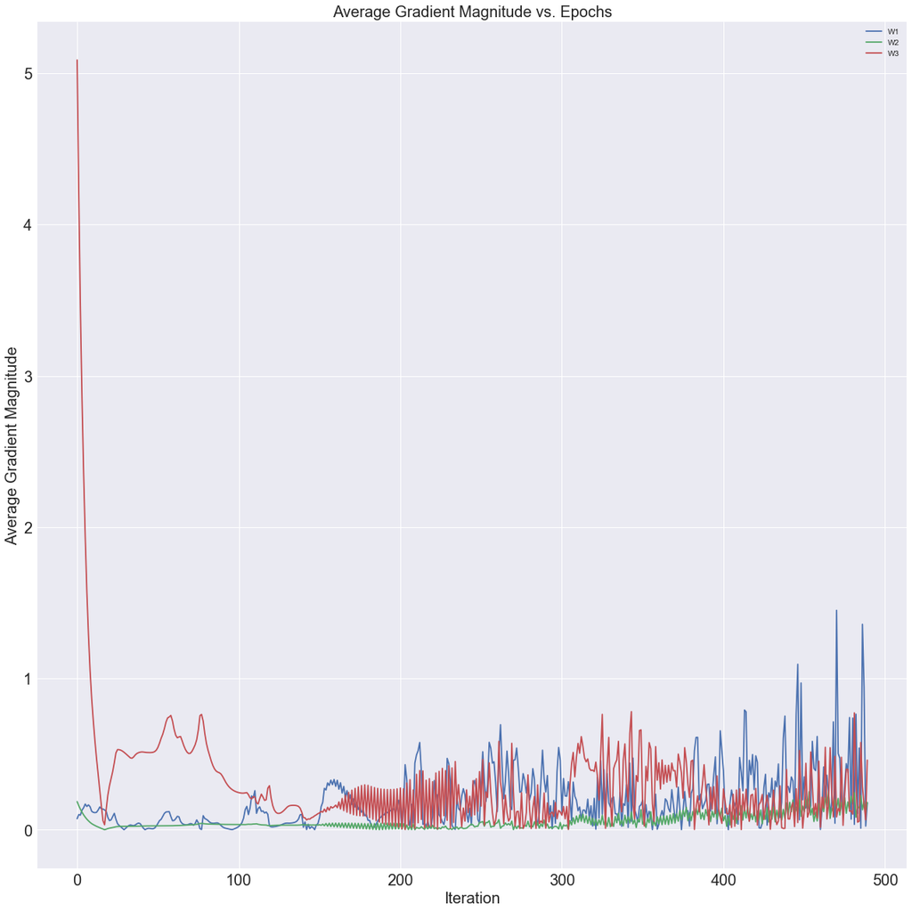

```python
ax = plt.subplot(1,1,1)
plt.plot(abs(NN.G1_avg_[10:]), label='W1')
plt.plot(abs(NN.G2_avg_[10:]), label='W2')
plt.plot(abs(NN.G3_avg_[10:]), label='W3')

plt.legend()
plt.ylabel('Average gradient magnitude')
plt.xlabel('Iteration', size = 20)
plt.ylabel('Average Gradient Magnitude', size = 20)
plt.xticks(size = 20)
plt.yticks(size = 20)
plt.title('Average Gradient Magnitude vs. Epochs', size = 20)
plt.show()
```

No. The gradients do not stay consistent in each layer as seen by the Average Gradient Magnitude graph above. As seen, the gradient in the third layer trains very quickly, which makes sense do to backpropagation as it is the first layer to undergo training. The gradient in the second layer is fairly well behaved, while the gradients in the first and third layers are not. In looking at the gradients over the iterations, we can see they start to "blow up" as the number of iterations increases. In terms of a neural network, this means the the network is not going to be able to learn long-term temporal relations from our data[1]. This could caused by our data set or our custom variable layer perceptron implementation.

[1]https://www.quora.com/Why-is-it-a-problem-to-have-exploding-gradients-in-a-neural-net-especially-in-an-RNN